# Tutorial Part II — R goes Spatial

## Visualising vector data

#### `plot()`

It is ok to use a simple `plot()` function for `{sf}` objects. However, mind that this object has 7 columns, so each column holds information that will be plotted, i.e. you will plot 7 single plots. So do a little transformation: either plot just one column with the geometry or define it as `{sp}` object:

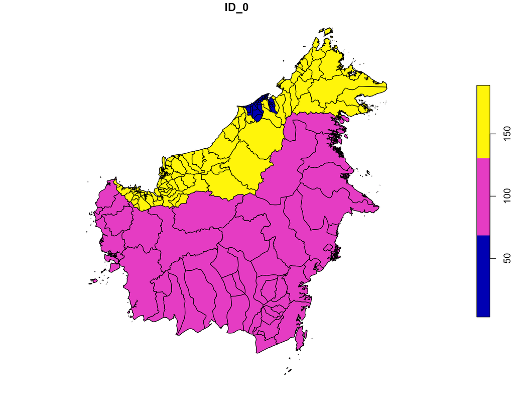

```r
# plot(Borneo_shp) ## not run!
plot(Borneo_shp[,1]) ## select column 1 or
```

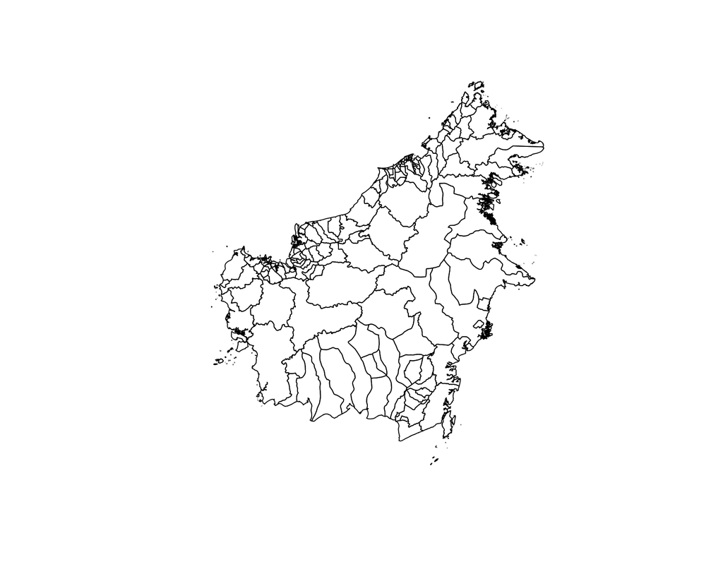

```r
plot(st_geometry(Borneo_shp))
```

Plotting `{sp}` objects:

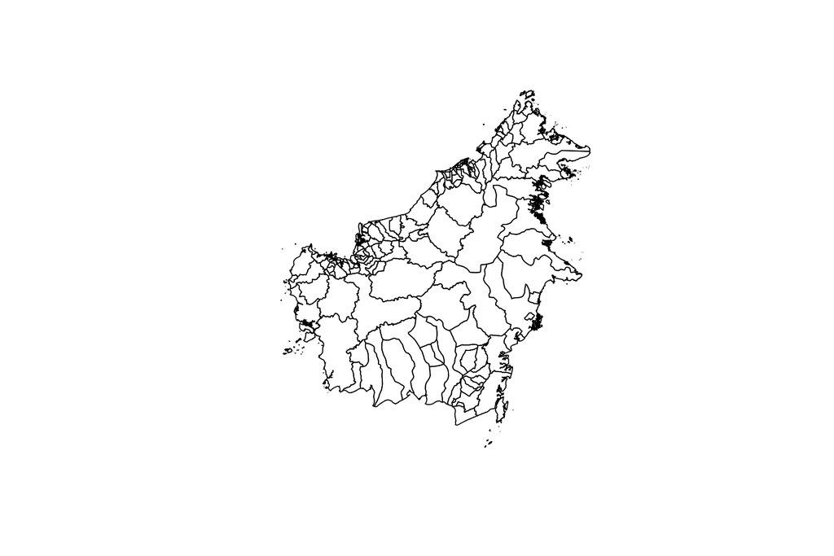

```r
## Defining it as(..., "Spatial"), i.e. transforming it to a `{sp}` object (see above)
plot(as(Borneo_shp, "Spatial")) ## plot geometry without information of a col
```

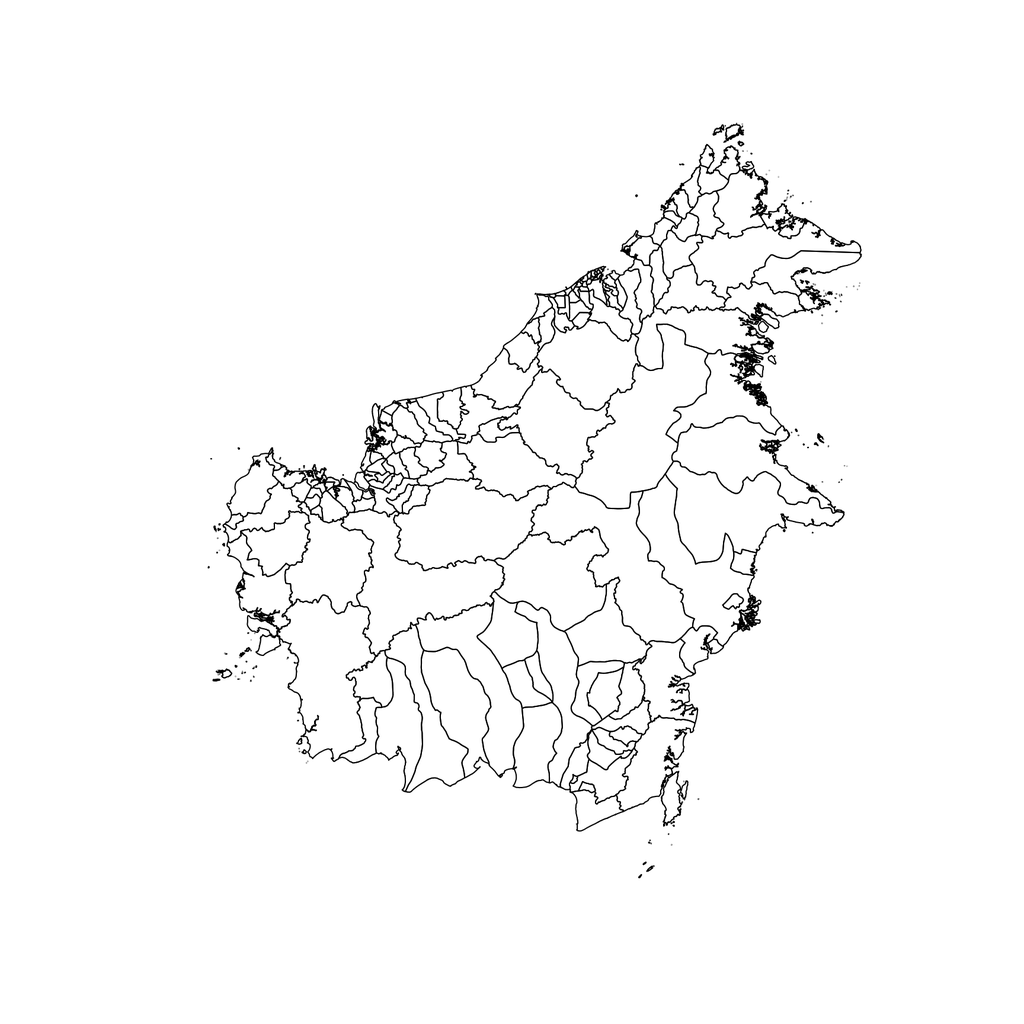

```r
plot(Admin_sp) ## ending _sp shows it as an `{sp}` object
```

Points in `data.frames` can be plotted, as long as the coordinates are the same, can also be plotted in space. We first plot the polygon, then add the points (note, one is a simple `data.frame`, the other is a shapefile):

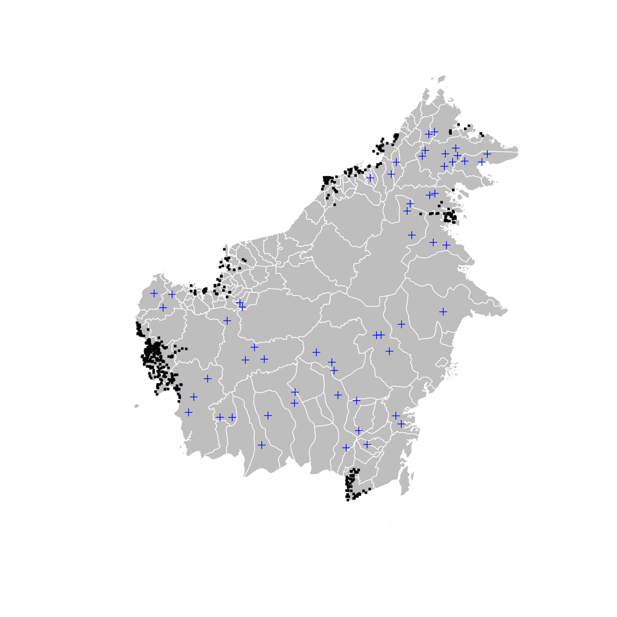

```r
plot(x = as(Borneo_shp, "Spatial"), col = 'grey', border = 'white') ## polygon
points(x = df_recs$long, df_recs$lat, cex = 0.5, pch = 15) ## simple d.f.!
plot(x = as(pt_shp, "Spatial"), col = 'blue', add = TRUE)
```

#### `{ggplot2}` package

`{ggplot2}` is currently the best way to plot `{sf}` objects: https://www.r-spatial.org/r/2018/10/25/ggplot2-sf.html. The parameter `geom_sf()` is set here.

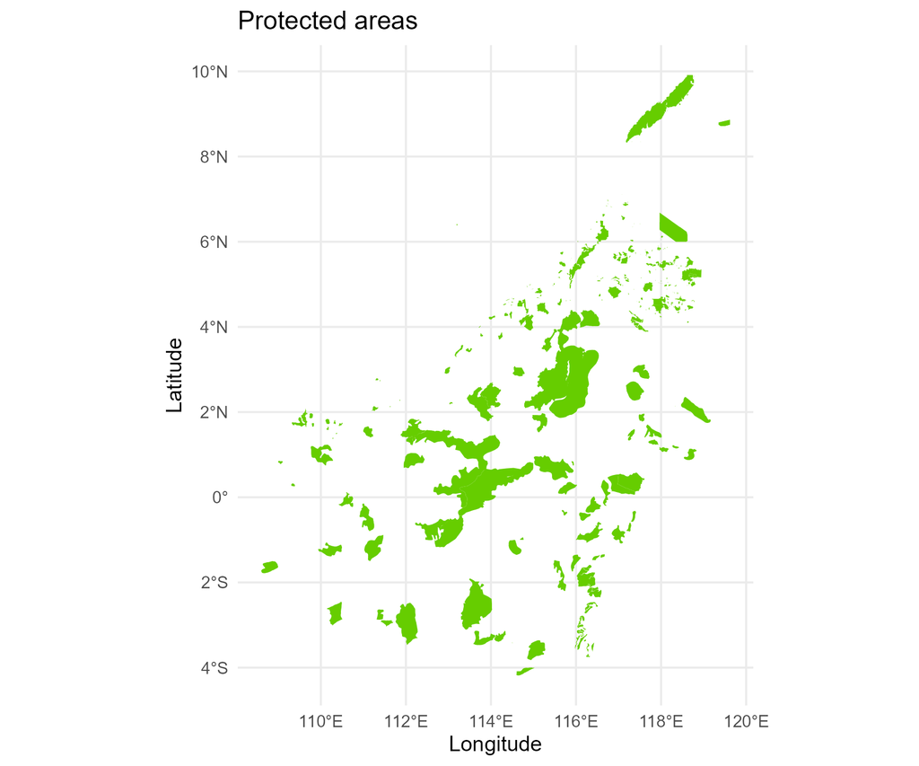

```r
ggplot(data = PA_shp) +
  geom_sf(fill = "chartreuse3", color = NA) +
  labs(x = "Longitude", y =  "Latitude",
       title = "Protected areas") +
  theme_minimal(base_size = 15) ## set custom plot style
```

Note that it does NOT work for `{sp}` objects (`SpatialPolygonsDataFrame`).

#### `{tmap}` package

*Static map*

The site ID is colour-coded here in a gradient. For further reading: https://tmap.geocompx.org/

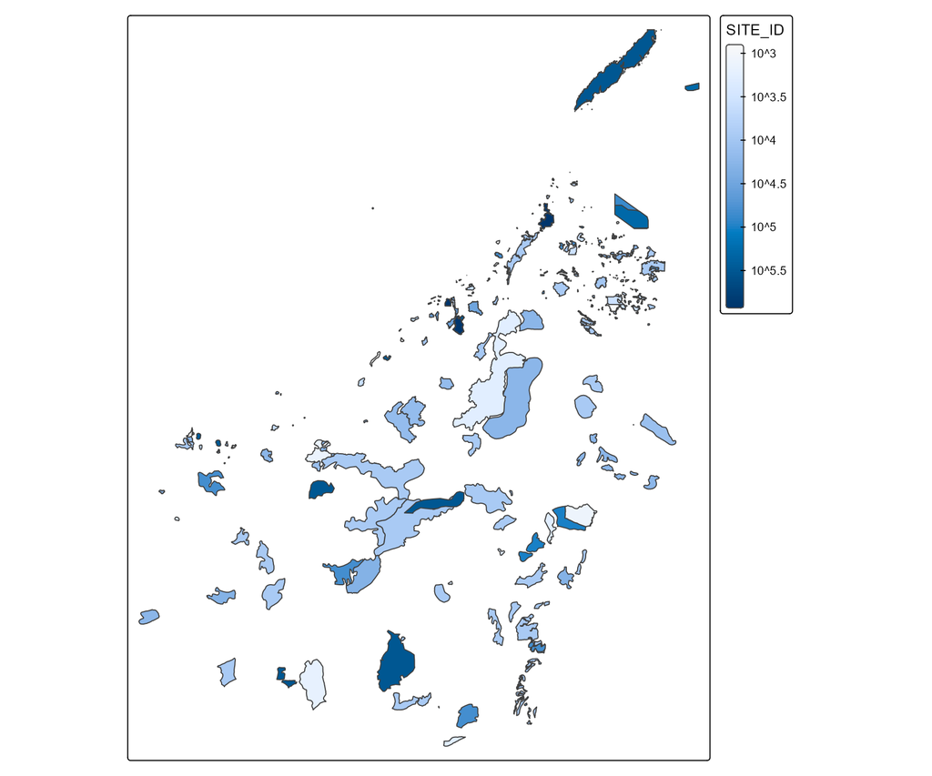

```r
tmap_mode(mode = "plot")

tm_shape(shp = PA_shp[, 1]) +
  tm_polygons(
      fill = "SITE_ID",
      fill.scale  = tm_scale_continuous_log10(),
    )
```

```r
## old V3 syle
#tm_shape(shp = PA_shp[, 1]) +
#  tm_polygons(col = "SITE_ID", palette = grDevices::terrain.colors(5))
```

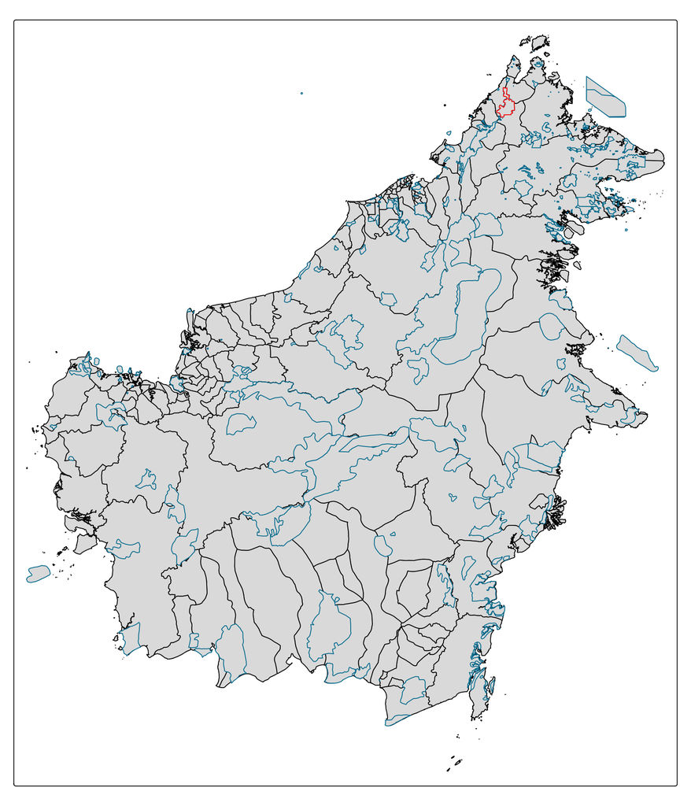

```r
tmap_mode(mode = "plot")

tm_shape(shp = Borneo_shp) +
    tm_polygons(col = "black") +
  tm_shape(PA_shp[,1]) +
    tm_polygons(col = "deepskyblue4") +
  tm_shape(PA_shp[1, ]) +
    tm_polygons(col = "red")
```

```r
## old V3 style
#tm_shape(shp = Borneo_shp) +
#    tm_polygons(border.col = "black") +
#  tm_shape(PA_shp[,1]) +
#    tm_polygons(border.col = "deepskyblue4") +
#  tm_shape(PA_shp[1, ]) +
#    tm_polygons(border.col = "red")
```

Add spatial points (note: it does not work with `data.frames`) to the plot.

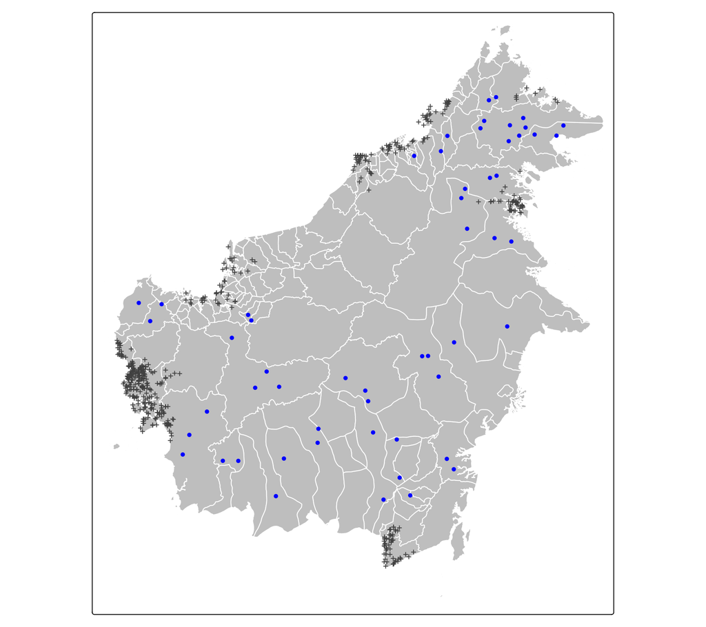

```r
tmap_mode(mode = "plot")

tm_shape(shp = Borneo_shp) +
    tm_polygons(fill = "grey", col = "white") +
  tm_shape(shp = recs_sf) +
    tm_dots(shape = 3, size = 0.25) +
  tm_shape(shp = pt_shp) +
    tm_dots(fill = "blue")
```

*Interactive map*

```r
tmap_mode(mode = "view")
tm_shape(shp = PA_shp[, 1]) +
  tm_polygons(fill = "SITE_ID", fill.scale  = tm_scale_continuous_log10())
```

[interactive chart not shown]

## Saving vector data

Work with subsets, select Malaysia, save and plot as shapefile with st_write():

```r
## select the protected areas of Malaysia only:
Mal_PA_shp <- subset(PA_shp, PA_shp$COUNTRY == 'Malaysia')

st_write(obj = Mal_PA_shp,
         dsn = output_wd,
         layer = 'ProtectedAreasMalaysia',
         driver = 'ESRI Shapefile',
         delete_layer = TRUE)
```

```
## Deleting layer `ProtectedAreasMalaysia' using driver `ESRI Shapefile'
## Writing layer `ProtectedAreasMalaysia' to data source
##   `C:/Users/wenzler/Documents/GitHub/d6_teaching_collection/output' using driver `ESRI Shapefile'
## Writing 153 features with 4 fields and geometry type Multi Polygon.
```

## Geospatial calculation

This refers to the GIS functions of area calculations, distance calculations, spatial overlays and intersections. The new `{sf}` package has the same functionality, with functions starting with `st_`, e.g. `st_buffer()`, `st_intersection()` etc.

- https://geocompr.robinlovelace.net/spatial-operations.html
- https://r.geocompx.org/geometry-operations#clipping

### Area calculation

Returns the area in square meters for all features:

```r
# st_area(x = Borneo_shp) ## returns long vector
head(st_area(x = Borneo_shp))
```

```
## Units: [m^2]
## [1] 7651059265 1238543644  486042067 6128271711 1468016456 2955188183
```

Hint: you can also calculate the area for single features (e.g. one polygon).

```r
st_area(x = Borneo_shp[3, ]) ## for a single polygon
```

```
## 486042067 [m^2]
```

Example: Calculate area of Malaysia in km²

```r
Mal_Borneo_shp <- subset(Borneo_shp, Borneo_shp$NAME_0 == 'Malaysia')
head(st_area(x = Mal_Borneo_shp) / 1000000) ## or / 1e6
```

```
## Units: [m^2]
## [1] 7651.0593 1238.5436  486.0421 6128.2717 1468.0165 2955.1882
```

```r
## better: use set_units to change the units from m^2 to km^2
Mal_Borneo_shp$area <- units::set_units(x = st_area(x = Mal_Borneo_shp), value = km^2)
head(Mal_Borneo_shp$area)
```

```
## Units: [km^2]
## [1] 7651.0593 1238.5436  486.0421 6128.2717 1468.0165 2955.1882
```

### CRS projection

Recap: If no CRS is assigned for a file, the CRS can be set with `st_crs()`. However, if a file has already a CRS, e.g. WGS84 (angular units, longitude and latitude), and you want to change into a projection with planar units (e.g. meters), use `st_transform()`.

```r
Borneo_shp_moll <-  st_transform(Borneo_shp, c("+proj=moll +datum=WGS84"))
class(Borneo_shp_moll) # sf object, data.frame!
```

```
## [1] "sf"         "data.frame"
```

Plot it and have a look at the changes:

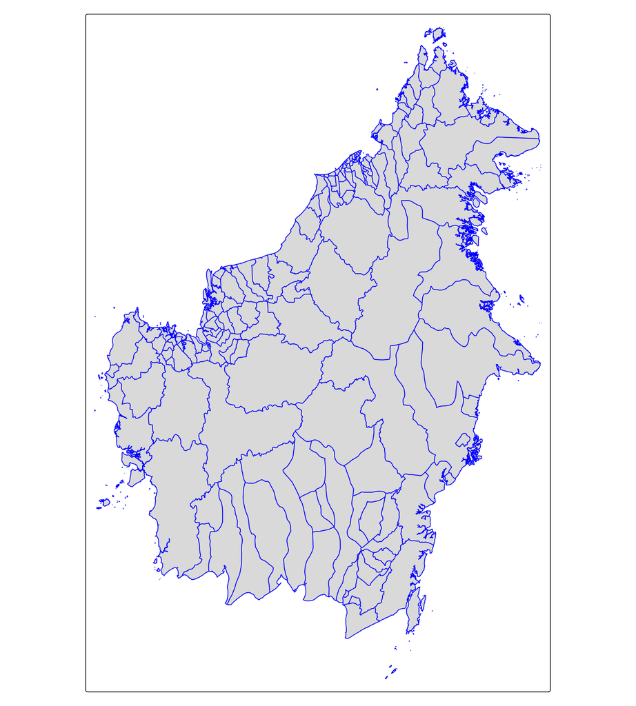

```r
tmap_mode(mode = "plot")
tm_shape(shp = Borneo_shp_moll) +
  tm_polygons(col = "blue") ## do you see the difference?
```

We can also use pretty `{ggplot2}` with `{sf}` objects:

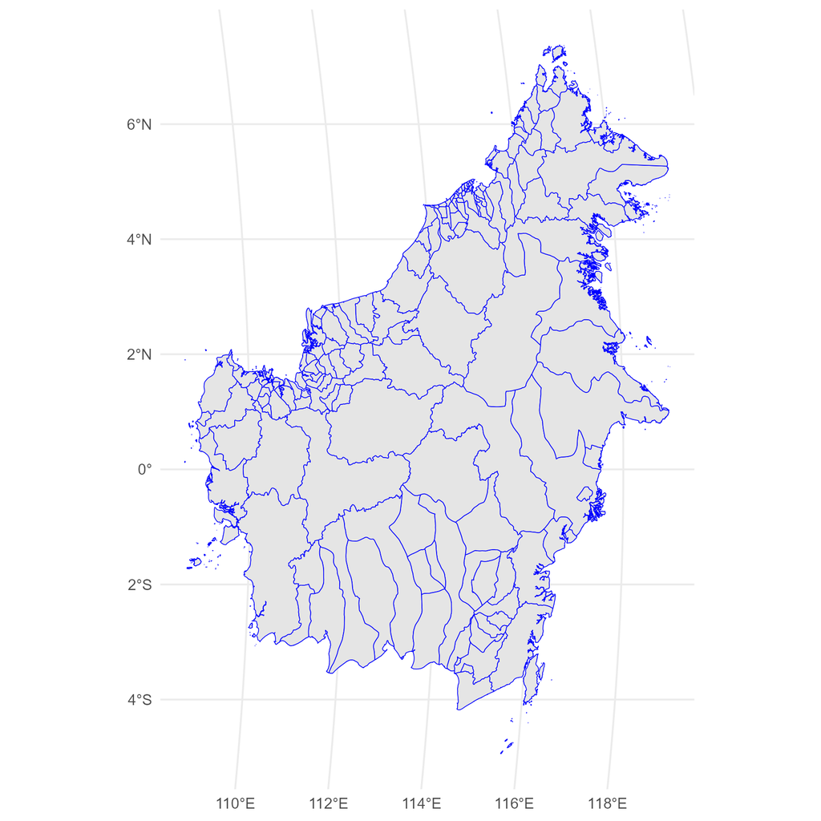

```r
ggplot(Borneo_shp_moll) +
  geom_sf(color = "blue") +
  theme_minimal(base_size = 15) ## set custom plot style
```

Note the change in the area calculation!

```r
head(st_area(x = Borneo_shp_moll))
```

```
## Units: [m^2]
## [1] 7666715202 1241315346  487129643 6141990607 1471302821 2961802507
```

```r
head(st_area(x = Borneo_shp))
```

```
## Units: [m^2]
## [1] 7651059265 1238543644  486042067 6128271711 1468016456 2955188183
```

Example: Add the area of a polygon as new column to a.t.

```r
## create the column 'area_km2'
area_km2 <- set_units(x = st_area(x = Borneo_shp_moll, byid = TRUE), value = km^2)
Borneo_shp_moll = data.frame(Borneo_shp_moll, area_km2)
head(x = Borneo_shp_moll)
```

```
##   ID_0 ISO   NAME_0 NAME_1     NAME_2 Shape_Leng Shape_Area
## 1  158 MYS Malaysia  Sabah Lahad Datu  6.7475367 0.62106012
## 2  158 MYS Malaysia  Sabah      Papar  1.6727672 0.10065591
## 3  158 MYS Malaysia  Sabah  Penampang  0.9548857 0.03951545
## 4  158 MYS Malaysia  Sabah Pensiangan  4.0257859 0.49725547
## 5  158 MYS Malaysia  Sabah      Pitas  2.9223456 0.11955352
## 6  158 MYS Malaysia  Sabah      Ranau  2.4815704 0.24027591
##                         geometry         area_km2
## 1 MULTIPOLYGON (((11824461 58... 7666.7152 [km^2]
## 2 MULTIPOLYGON (((11590069 72... 1241.3153 [km^2]
## 3 MULTIPOLYGON (((11592912 72...  487.1296 [km^2]
## 4 MULTIPOLYGON (((11651495 62... 6141.9906 [km^2]
## 5 MULTIPOLYGON (((11703665 83... 1471.3028 [km^2]
## 6 MULTIPOLYGON (((11675075 77... 2961.8025 [km^2]
```

### Spatial overlay and intersections

#### Points and polygons with `st_intersection()`

Now we want to know which of our species observations (recs_sf) were taken in protected areas (PA_shp). For this, we use `st_intersection()`:

```r
## retrieve the geometry (location) indices of PA_shp at
## the locations of sp_recs: which points are in PA_shp
nrow(recs_sf) ## 500
```

```
## [1] 500
```

```r
insidePA <- st_intersection(x = recs_sf, y = PA_shp) ## takes some seconds ##what does the warning mean?
nrow(insidePA) ## 11
```

```
## [1] 11
```

#### Point and raster data with `extract()`

Then we want to know in which climatic zone we have observed the species ‘recs_sf’. For this, we extract the information from the raster of mean annual temperature (ras_bio_asc_01) to the point locations of species observations:

```r
## for a RASTER: extract mean ann. temp. from ras_bio_asc_01
## and add it to a.t.of the locations/ points
mean_t <- extract(x = ras_bio_asc_01, y = vect(recs_sf)) ## for {terra} we need to wrap the sf object into spatial vector with`vect()`
recs_sf$mean_t <- mean_t$bio_asc_01
mean(x = recs_sf$mean_t) # hist(sp_recs_sf$mean_t)
```

```
## [1] 272.7788
```

#### Polygon and raster data with `extract()`

Finally, we want to know in which elevation range our protected areas are located. Extract elevation per PA and save average to attribute table of the shapefile/ vector data as a new column. The elevation raster was uploaded as ras_bio_asc_24 (see above, raster data section).

```r
fewPA <- Mal_PA_shp[c(1:5), 1] ## select only 5 PAs to speed up computation

## returns a data.frame — each ID contains multiple elevation raster cells (ras_bio_asc_24).
## the shapefile has to be turned into a spatial vector
tmp <- extract(x = ras_bio_asc_24, y = vect(fewPA), xy = TRUE)
str(tmp) ## overview over the 'data.frame' object. It should have 5 IDs for example. Let's check:
```

```
## 'data.frame':    3681 obs. of  4 variables:
##  $ ID        : num  1 1 1 1 1 1 1 1 1 1 ...
##  $ bio_asc_24: int  286 491 508 500 775 986 645 582 335 675 ...
##  $ x         : num  117 117 117 117 117 ...
##  $ y         : num  6.49 6.49 6.48 6.48 6.48 ...
```

```r
unique(tmp$ID)
```

```
## [1] 1 2 3 4 5
```

```r
## As a protector area feature of the shapefile comprises several elevation raster cells,
## they are all appended in the extracted data.frame
head(tmp)
```

```
##   ID bio_asc_24        x        y
## 1  1        286 116.5800 6.488488
## 2  1        491 116.5883 6.488488
## 3  1        508 116.5800 6.480154
## 4  1        500 116.5883 6.480154
## 5  1        775 116.5966 6.480154
## 6  1        986 116.6050 6.480154
```

```r
## use tapply (see course 1 - R Intro) to check the values.
## The protected area with ID = 1 seems to comprise high elevation
PA_elev <- tapply(X=tmp$bio_asc_24, INDEX = tmp$ID, FUN = mean)
PA_elev
```

```
##         1         2         3         4         5
## 1348.4446  554.8083  107.7250  512.3037  403.9674
```

```r
## you can either transform this info to a data.frame....
PA_elev <- data.frame(PA_elev)
PA_elev
```

```
##     PA_elev
## 1 1348.4446
## 2  554.8083
## 3  107.7250
## 4  512.3037
## 5  403.9674
```

Append mean elevation to the shapefile:

```r
## ...or use function 'aggregate()'. this returns a `data.frame`.
## The elevation info is in column 'x'
mean_tmp <- terra::aggregate(tmp$bio_asc_24, by = list(Category = tmp$ID), FUN = mean)


## Since both objects, the shapefile 'fewPA' and the data.frame 'mean_tmp' (or 'PA_elev')
## are ordered by ID,
## you can directly append the information to the attribute table of 'fewPA'
fewPA$mean_elevation <- mean_tmp$x
#fewPA$mean_elevation <- PA_elev ## alternatively

fewPA
```

```
## Simple feature collection with 5 features and 2 fields
## Geometry type: MULTIPOLYGON
## Dimension:     XY
## Bounding box:  xmin: 111.8754 ymin: 1.32105 xmax: 118.0747 ymax: 6.4952
## Geodetic CRS:  WGS 84
##   SITE_ID                       geometry mean_elevation
## 1     785 MULTIPOLYGON (((116.5979 6....      1348.4446
## 2     787 MULTIPOLYGON (((114.9033 4....       554.8083
## 3     791 MULTIPOLYGON (((113.7986 3....       107.7250
## 4     795 MULTIPOLYGON (((117.8497 4....       512.3037
## 5    1300 MULTIPOLYGON (((112.2054 1....       403.9674
```

# Spatial data sources in the web

We have now also completely outsourced this chapter onto our coding wiki website:

https://ecodynizw.github.io/posts/r-spatial-data/

## `{rnaturalearth}`

[NaturalEarth](http://www.naturalearthdata.com) (http://www.naturalearthdata.com) is a public domain map data set that features vector and raster data of physical and cultural properties. It is available at 1:10m, 1:50m, and 1:110 million scales.

[`{rnaturalearth}`](https://docs.ropensci.org/rnaturalearth) (https://docs.ropensci.org/rnaturalearth) is an R package to hold and facilitate interaction with NaturalEarth (ne_…) map data.

After loading the package, you can for example quickly access shapefiles of all countries that are already projected and can be stored as either `sp` or `sf` objects:

```r
library(rnaturalearth)

## store as sf object (simple features)
world <- ne_countries(returnclass = "sf")
class(world)
```

```
## [1] "sf"         "data.frame"
```

```r
sf::st_crs(world)[1]
```

```
## $input
## [1] "WGS 84"
```

This country data set (which is actually not downloaded but stored locally by installing the package) already contains several useful variables, mostly referring to different naming conventions (helpful when joining with other data sets), to identify continents and regions, and also some information on population size, GDP, and economy:

```r
names(world) ## takes some seconds to compute
```

```
##   [1] "featurecla" "scalerank"  "labelrank"  "sovereignt" "sov_a3"
##   [6] "adm0_dif"   "level"      "type"       "tlc"        "admin"
##  [11] "adm0_a3"    "geou_dif"   "geounit"    "gu_a3"      "su_dif"
##  [16] "subunit"    "su_a3"      "brk_diff"   "name"       "name_long"
##  [21] "brk_a3"     "brk_name"   "brk_group"  "abbrev"     "postal"
##  [26] "formal_en"  "formal_fr"  "name_ciawf" "note_adm0"  "note_brk"
##  [31] "name_sort"  "name_alt"   "mapcolor7"  "mapcolor8"  "mapcolor9"
##  [36] "mapcolor13" "pop_est"    "pop_rank"   "pop_year"   "gdp_md"
##  [41] "gdp_year"   "economy"    "income_grp" "fips_10"    "iso_a2"
##  [46] "iso_a2_eh"  "iso_a3"     "iso_a3_eh"  "iso_n3"     "iso_n3_eh"
##  [51] "un_a3"      "wb_a2"      "wb_a3"      "woe_id"     "woe_id_eh"
##  [56] "woe_note"   "adm0_iso"   "adm0_diff"  "adm0_tlc"   "adm0_a3_us"
##  [61] "adm0_a3_fr" "adm0_a3_ru" "adm0_a3_es" "adm0_a3_cn" "adm0_a3_tw"
##  [66] "adm0_a3_in" "adm0_a3_np" "adm0_a3_pk" "adm0_a3_de" "adm0_a3_gb"
##  [71] "adm0_a3_br" "adm0_a3_il" "adm0_a3_ps" "adm0_a3_sa" "adm0_a3_eg"
```

[output cut: 19 more lines]

We can quickly plot it:

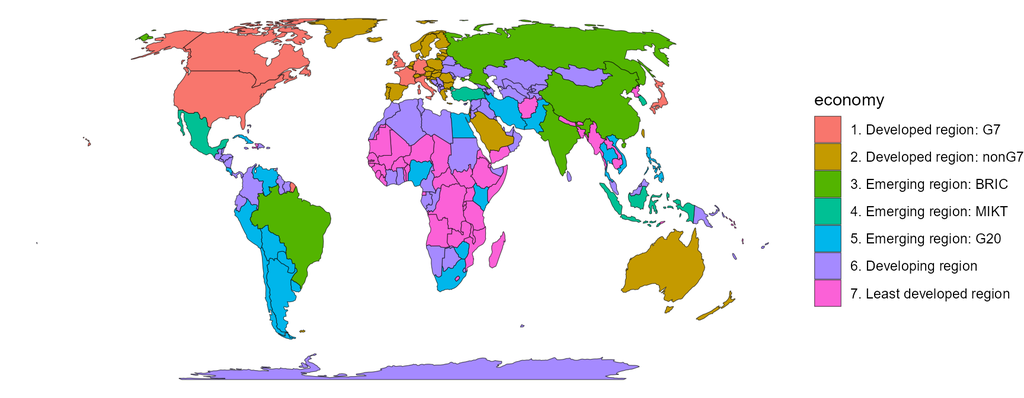

```r
ggplot(world) +
  geom_sf(aes(fill = economy)) +
  coord_sf(crs = "+proj=eqearth") +
  theme_void()
```

**NOTE:** Unfortunately, NaturalEarth is using [weird *de-facto* and *on-the-ground rules* to define country borders which do not follow the borders the UN and most countries agree on](https://github.com/nvkelso/natural-earth-vector/issues/391). For correct and official borders, please use the {rgeoboundaries} package (see below).

You can specify the scale, category and type you want as in the examples below.

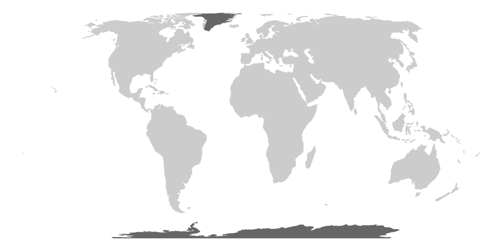

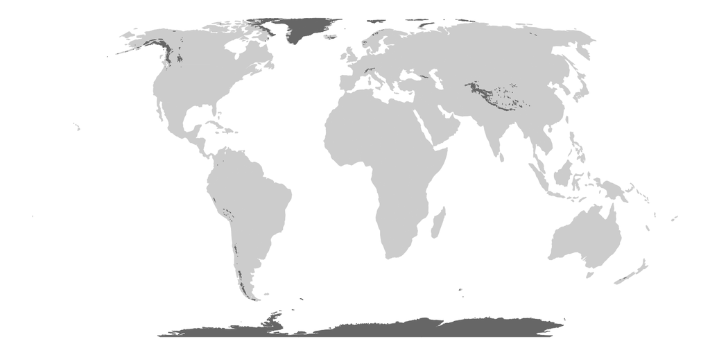

```r
glacier_small <- ne_download(type = "glaciated_areas", category = "physical",
                             scale = "small", returnclass = "sf")

glacier_large <- ne_download(type = "glaciated_areas", category = "physical",
                             scale = "large", returnclass = "sf")

ggplot() +
  geom_sf(data = world, color = "grey80", fill ="grey80") +
  geom_sf(data = glacier_small, color = "grey40", fill = "grey40") +
  coord_sf(crs = "+proj=eqearth") +
  theme_void()

ggplot() +
  geom_sf(data = world, color = "grey80", fill ="grey80") +
  geom_sf(data = glacier_large, color = "grey40", fill = "grey40") +
  coord_sf(crs = "+proj=eqearth") +
  theme_void()
```

## `{rgeoboundaries}`

The [`{rgeoboundaries}` package](https://github.com/wmgeolab/rgeoboundaries) uses the Global Database of Political Administrative Boundaries that provide generally accepted political borders. The data are licensed openly.

```r
#install.packages("remotes")
#remotes::install_github("wmgeolab/rgeoboundaries")
## you might need to install 'hoardr' manually

library(rgeoboundaries)
## you might be asked to create a cache folder -> click yes


## the following takes a while to load. Be patient.
gb_adm0() ## political boundary file
```

```
## Simple feature collection with 218 features and 3 fields
## Geometry type: MULTIPOLYGON
## Dimension:     XY
## Bounding box:  xmin: -180 ymin: -90 xmax: 180 ymax: 83.63339
## Geodetic CRS:  WGS 84
## First 10 features:
##    shapeGroup shapeType         shapeName                       geometry
## 1         AFG      ADM0       Afghanistan MULTIPOLYGON (((74.88986 37...
## 2         GBR      ADM0    United Kingdom MULTIPOLYGON (((33.01302 34...
## 3         ALB      ADM0           Albania MULTIPOLYGON (((20.07889 42...
## 4         DZA      ADM0           Algeria MULTIPOLYGON (((8.641941 36...
## 5         USA      ADM0     United States MULTIPOLYGON (((-168.1579 -...
## 6         ATA      ADM0        Antarctica MULTIPOLYGON (((-60.06171 -...
## 7         ATG      ADM0 Antigua & Barbuda MULTIPOLYGON (((-62.34839 1...
## 8         ARG      ADM0         Argentina MULTIPOLYGON (((-63.83417 -...
## 9         AND      ADM0           Andorra MULTIPOLYGON (((1.725802 42...
## 10        AGO      ADM0            Angola MULTIPOLYGON (((11.7163 -16...
```

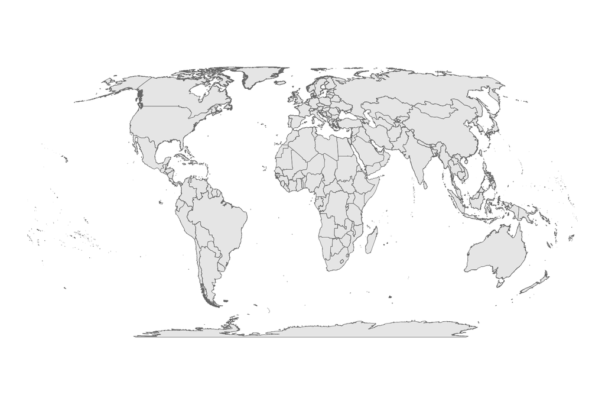

```r
## plotting takes a long time!!!
ggplot(gb_adm0()) +
  geom_sf(color = "grey40", lwd = .2) +
  coord_sf(crs = "+proj=eqearth") +
  theme_void()
```

Lower administrative levels are available as well, e.g. in Germany adm1 represents federal states (“Bundesländer”), adm2 districts (“Kreise”) and so on.

Let’s plot the admin 1 levels for the DACH countries:

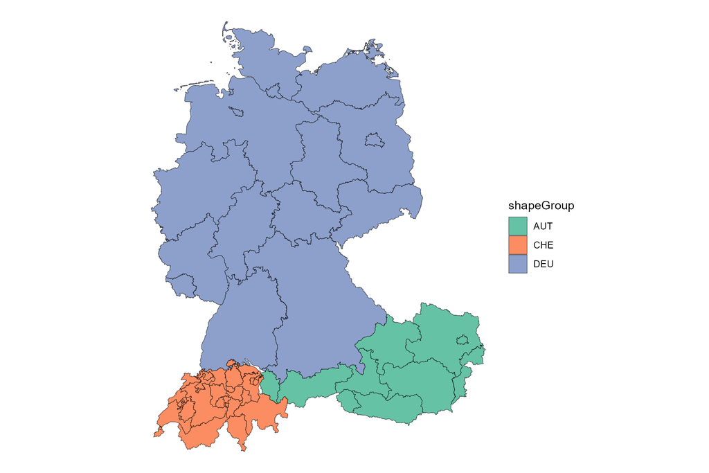

```r
dach <- gb_adm1(c("germany", "switzerland", "austria"), type = "sscgs")

ggplot(dach) +
  geom_sf(aes(fill = shapeGroup)) +
  scale_fill_brewer(palette = "Set2") +
  theme_void()
```

## `{osmdata}`

[OpenStreetMap](https://www.openstreetmap.org) is a collaborative project to create a free editable geographic database of the world. The geodata underlying the maps is considered the primary output of the project and is accessible from R via the `{osmdata}` package.

We first need to define our query and limit it to a region. You can explore the features and tags (also available as information via OpenStreetMap directly).

```r
library(osmdata)

## explore features + tags
head(available_features())
```

```
## [1] "abutters"    "access"      "addr:*"      "admin_level" "aeroway"
## [6] "amenity"
```

```r
head(available_tags("craft"))
```

```
## # A tibble: 6 × 2
##   Key   Value
##   <chr> <chr>
## 1 craft agricultural_engines
## 2 craft atelier
## 3 craft bag_repair
## 4 craft bakery
## 5 craft basket_maker
## 6 craft beekeeper
```

```r
## building the query, e.g. beekeepers

  ## you can automatically retrieve a bounding box (pr specify one manually)
bounding_box <- getbb(place_name = "Berlin")
  ## build an Overpass query
query <- opq(bbox = bounding_box)
  ## access particular feature
beekeeper_query <- add_osm_feature(opq = query,
                                   key = "craft",
                                   value = "beekeeper")

## download data
sf_beekeepers <- osmdata_sf(beekeeper_query)
```

Now we can investigate beekeepers in Berlin:

```r
names(sf_beekeepers)
```

```
## [1] "bbox"              "overpass_call"     "meta"
## [4] "osm_points"        "osm_lines"         "osm_polygons"
## [7] "osm_multilines"    "osm_multipolygons"
```

```r
head(sf_beekeepers$osm_points)
```

```
## Simple feature collection with 6 features and 41 fields
## Geometry type: POINT
## Dimension:     XY
## Bounding box:  xmin: 13.24443 ymin: 52.35861 xmax: 13.69093 ymax: 52.573
## Geodetic CRS:  WGS 84
##              osm_id name addr:city addr:country addr:housenumber addr:postcode
## 358407135 358407135 <NA>      <NA>         <NA>             <NA>          <NA>
## 358407138 358407138 <NA>      <NA>         <NA>             <NA>          <NA>
## 417509803 417509803 <NA>      <NA>         <NA>             <NA>          <NA>
## 417509805 417509805 <NA>      <NA>         <NA>             <NA>          <NA>
## 597668310 597668310 <NA>      <NA>         <NA>             <NA>          <NA>
## 597668311 597668311 <NA>      <NA>         <NA>             <NA>          <NA>
##           addr:street addr:suburb check_date check_date:currency:XBT
## 358407135        <NA>        <NA>       <NA>                    <NA>
## 358407138        <NA>        <NA>       <NA>                    <NA>
```

[output cut: 46 more lines]

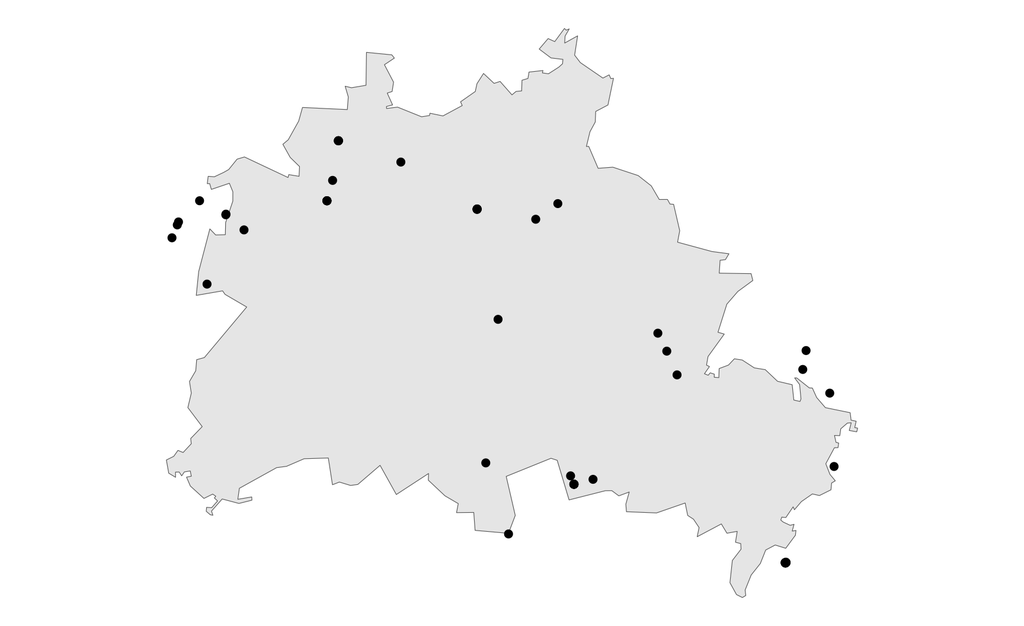

```r
beekeper_locations <- sf_beekeepers$osm_points

gb_ber <- gb_adm1(c("germany"), type = "sscgs")[3,] # the third element is Berlin

ggplot(beekeper_locations) +
  geom_sf(data = gb_ber) +
  # geom_sf(data = d6berlin::sf_berlin) + ## alternative to geoboundaries, but d6berlin needs to be loaded first
  geom_sf(size = 2) +
  theme_void()
```

## `{elevatr}`

The [`{elevatr}`](https://github.com/jhollist/elevatr/) (https://github.com/jhollist/elevatr/) is an R package that provides access to elevation data from AWS (Amazon Web Services) Open Data Terrain Tiles and the Open Topography Global data sets API (application programming interface) for raster digital elevation models (DEMs).

We first need to define a location or bounding box for our elevation data. This can either be a data frame or a spatial object. We use an `sf` object which holds the projection to be used when assessing the elevation data:

```r
library(elevatr)

## manually specify corners of the bounding box of the US
bbox_usa <- data.frame(x = c(-125.0011, -66.9326),
                   y = c(24.9493, 49.5904))

## turn into spatial, projected bounding box
sf_bbox_usa <- st_as_sf(bbox_usa, coords = c("x", "y"), crs = 4326)
```

Now we can download the elevation data with a specified resolution z (ranging from 1 to 14 with 1 being very coarse and 14 being very fine).

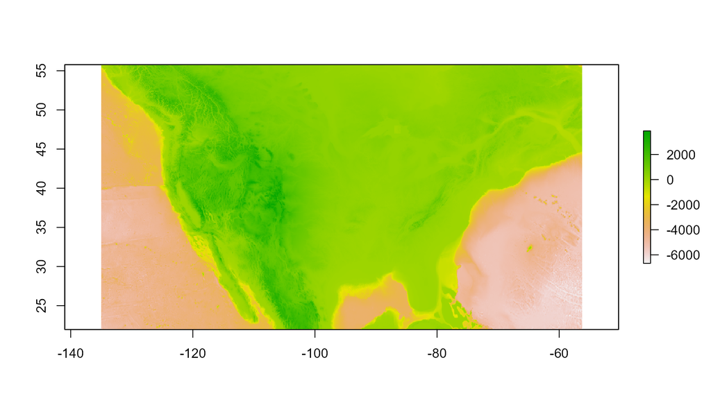

```r
elev_usa <- get_elev_raster(locations = sf_bbox_usa, z = 5)

plot(elev_usa)
```

**Optional - composite plots**

# Composite plots: plotting several layers and data types

*Simple composite plot*

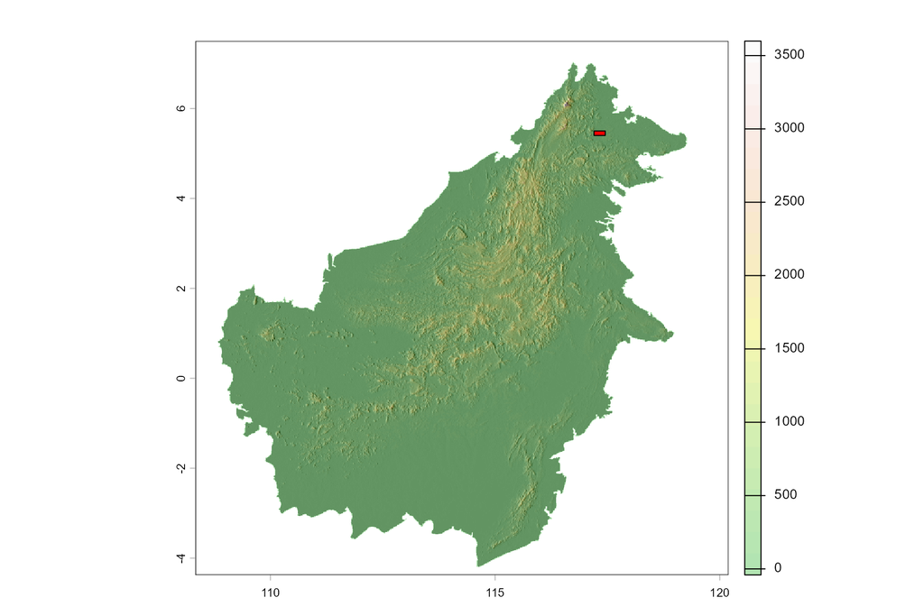

```r
plot(Bor_hs, col = grey(0:100/100), legend = FALSE)
plot(ras_bio_asc_24, col = terrain.colors(25, alpha = 0.3), add = TRUE)
points(crds(ras_bio_asc_01_cr), cex = 0.1, pch = '+')
plot(ext(ras_bio_asc_01_cr), add = TRUE, col = 'red')
```

*Composite plot with `{tmap}`*

In the following, we will create a `SpatialPointDataFrame` from the small clipped/ cropped raster with the `{sf}` package and plot it on top of the hillshade. Use the possibility of selecting/ disregarding different layers (layer icon on the left).

```r
hillsh <- Bor_hs

# make sf object from coordinates of the raster
ras_bio_asc_01_cr_sf <- st_as_sf(
  data.frame(crds(ras_bio_asc_01_cr)),
  coords = c("x", "y"), ## define columns for the coordinates
  crs = 4326, ## define crs, 4326 is the EPSG code
  sf_column_name = "geometry" ## sf needs a geometry column and you have to name it
)
```

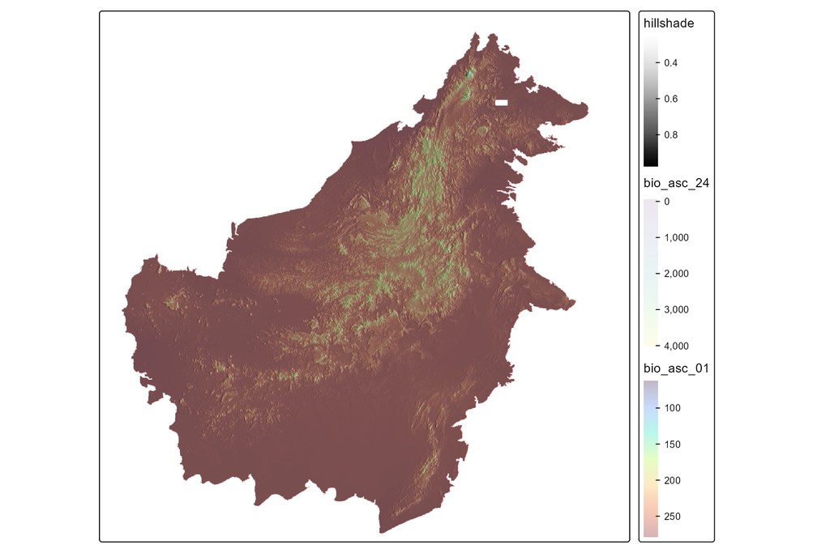

```r
# static plot
tmap_mode(mode = "plot")

tm_shape(shp = hillsh, raster.downsample = TRUE) +
    tm_raster(col.scale  = tm_scale_continuous(values = "brewer.greys")) +
tm_shape(shp = ras_bio_asc_24, raster.downsample = TRUE) +
    tm_raster(col.scale  = tm_scale_continuous(values = "viridis"), col_alpha = 0.1) +
tm_shape(shp = ras_bio_asc_01, raster.downsample = TRUE) +
    tm_raster(col.scale = tm_scale_continuous(values ="turbo"),
              col_alpha = 0.3) +
tm_shape(shp = ras_bio_asc_01_cr_sf) +
  tm_symbols(shape = 1, size = 0.05, col= 'white') ## or tm_dots()
```

Unfortunately, in `{tmap}` you can only use `shape = 1` and `shape = 20`, only circles are plotted.

https://tmap.geocompx.org/layers

*An Advanced Map with `{tmap}`*

At the end, an example of a beautiful map, created with `tmap`:

To do: transform tmap v3 code into v4:

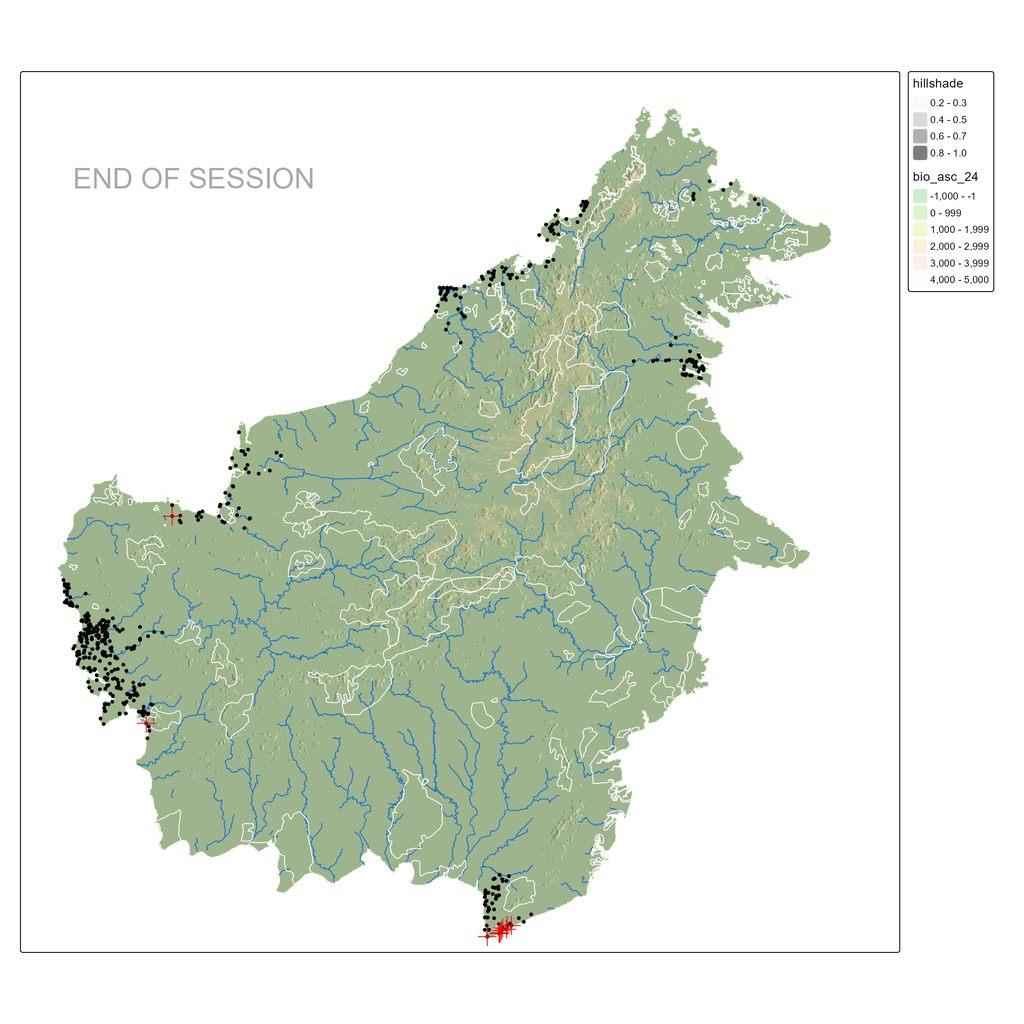

```r
tmap_mode(mode = "plot")

tm_shape(shp = hillsh) +
  ## hillshading
  tm_raster(palette = "Greys",
            legend.show = FALSE,
            alpha = 0.75) +
  ## topographical model
  tm_shape(shp = ras_bio_asc_24) +
  tm_raster(palette = terrain.colors(25),
            alpha = 0.2,
            legend.show = FALSE) +
  ## rivers
  tm_shape(shp = River_shp) +
  tm_lines(col = "dodgerblue3") +
  ## protected areas
  tm_shape(shp = PA_shp) +
  tm_polygons(border.col = "white",
              alpha = 0) +
  ## locations
  tm_shape(shp = recs_sf) +
  tm_dots(shape = 16,
          size = 0.3) +
  tm_shape(shp = insidePA) +
  tm_dots(col = "red",
          size = 1,
          shape = 3) +
  ## styling
  tm_layout(title = "END OF SESSION",
            title.color = "darkgrey",
            title.position = c(0.05, 0.9),
            title.size = 2)
```

End optional.

# Recap: the most important functions for spatial data

TL;DR ? (too long didn’t read?). Then at least remember the following most important commands for loading, projecting and saving spatial data.

## Load spatial data

```r
myraster       <- terra::rast()
myshapefile    <- sf::st_read()
myxydataframe  <- sf::st_as_sf()
```

## Assign CRS to or project spatial data into another CRS

```r
## Set/ assign the CRS if missing -> here with EPSG-code
crs(myraster)  <- "4326" ##assign if raster comes without CRS
st_crs(myshapefile, '3085')

## project it
myraster_proj  <- terra::project(myraster, 'EPSG:3085') ##example
myshapefile_prof <- sf::st_transform(myshapefile, 3085)
```

## Save spatial data

```r
terra::writeRaster() ## SpatRaster
sf::st_write()       ## vector data
```

# Course 2 Exercise 1

**Please hand in the R-Script and the plots. Please add your name or name of group to the file/script names.**

For example: myplotname_course2_ex1_yourlastname_yourfirstname.pdf/ or: .png/ or: .html and Rscript_course2_ex1_yourlastname_yourfirstname.Rmd/ or: .R

**Revisit the data set from course 1 on wild boar observations in Berlin: `data_wb_melden_en.csv`. (it is here: `....\d6_teaching_collection\data\data_berlin\animal_data`).

Now, we want to study the spatial patterns of the wild boar observations. We may hypothesize that wild boar observations are also related to local differences in weather. Answer the following question using spatial data sets and visualizations:**

- **Question 1.1) Were wild boar with many piglets seen more often in warm parts of the city?**
- **Question 1.2) Were wild boars more often observed at colder spots of the city during sunny weather?**
- **Question 1.3) *Additional question for the fast ones:* Were large groups of wild boar more frequently seen in areas providing a dense tree cover?**

Follow these steps to answer the questions:

- 1. Load the wild boar data (`data_wb_melden_en.csv`) and spatial data on temperature in Berlin (`summer_temp_100m_3035.asc` in `data_berlin`). Remember to set the correct CRS to the raster! (Hint: we need the Lambert Azimuthal Equal Area (LAEA) projection for Europe. Tip: always save the CRS as EPSG code to the filename ;-) )
- 2. Turn the wild boar data into a simple features object. Remember to set the correct CRS (the wild boar locations were collected in WGS 84) and to transform it to the same CRS as the raster afterwards!
- 3. Inspect both spatial data sets by plotting the temperature raster with the wild boar locations on top using the R basic plot function. The locations should match the map (if not something went wrong when setting the CRS; check if they are the same).
- 4. Select one of the temperature layers and extract the values for each wild boar location.
- 5. Create a plot that visualizes the temperature at each wild boar observation with 3 or more piglets (y axis) for each number of piglets (e.g. make a boxplot and plot the raw data on top).
- 6. Create a new variable that holds the weather category as either “sunny” or “other”.
- 7. Visualize the temperature at each wild boar observation (y axis) for sunny and other weather (box and whisker plot + raw data).
- 8. Save the wild boar observations with the local temperature information as an .Rds file.

For the additional question:

- 1. Load the tree cover data set (`tree_cover_density_2012_100m_3035.asc` in `data_berlin`).
- 10. Inspect the data set by plotting the raster using the R basic plot function.
- 11. Extract the tree cover within a buffer of 100m around each wild boar location (hint: use the help to inspect the arguments of `extract()`).
- 12. Create a boxplot that shows the tree cover (y axis) based on the group size.